# Лабораторная работа №14

Партиции, файловые системы, монтирование

Эзиз Хатамов

Российский университет дружбы народов, Москва, Россия

20 сентября 2025

# Цель работы

## Основная цель

Получение навыков разметки дисков (MBR/GPT), создания файловых систем, настройки области подкачки и монтирования разделов в Linux.

# Процесс работы

## Подключение дисков и проверка

- Подключены диски **/dev/sdb** и **/dev/sdc**
- Проверка: `fdisk -l`

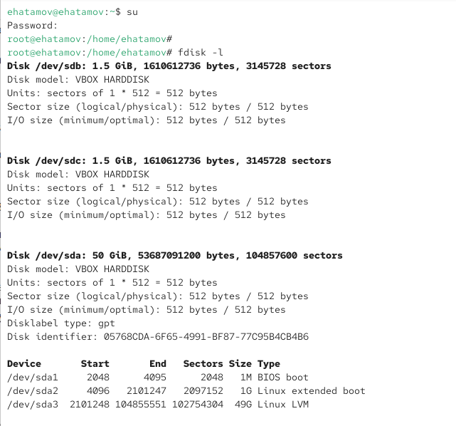

## Создание первичного раздела

- Создан раздел **/dev/sdb1**
- Размер: **300 MiB**
- Тип: Linux (MBR)

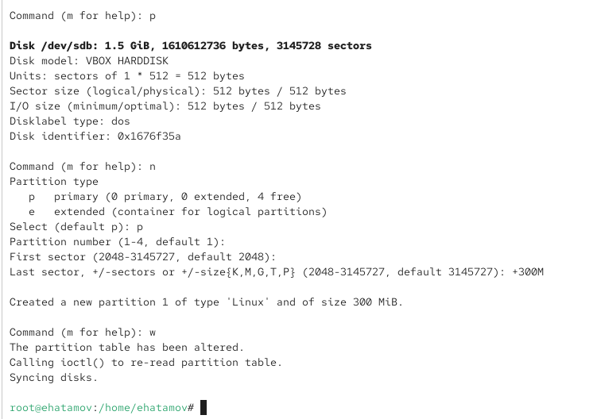

## Создание расширенного и логического разделов

- Создан расширенный раздел **sdb2**
- Логический раздел **sdb5** на 300 MiB

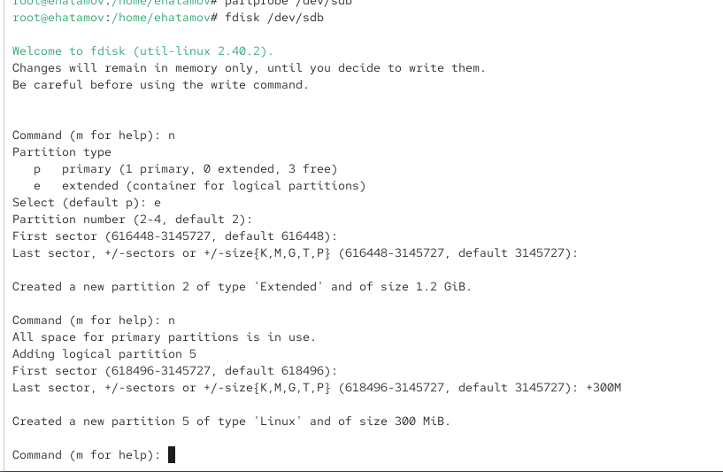

Расширенный и логический раздел

## Создание swap

- Создан **sdb6**
- Тип: **82 (Linux swap)**
- Активация: `mkswap`, `swapon`

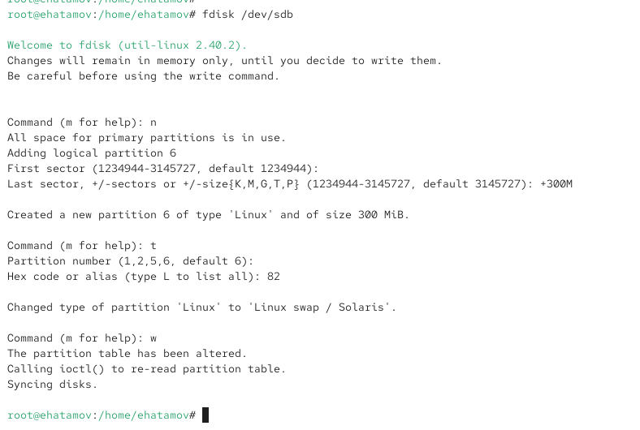

Создание swap

## Проверка структуры GPT-диска

- Используем диск **/dev/sdc**
- Разметка отсутствовала
- Создана новая GPT

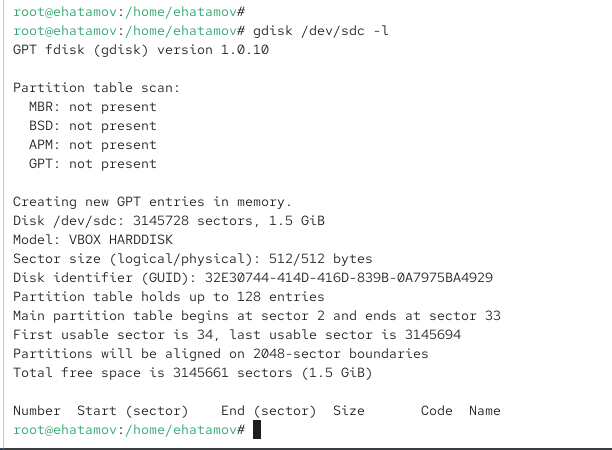

Проверка GPT

## Создание раздела GPT

- Раздел **sdc1**
- Размер: **300 MiB**
- Тип: **8300 — Linux filesystem**

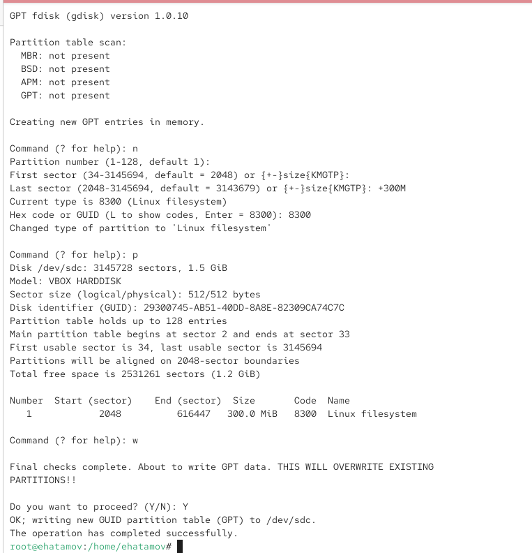

Создание GPT раздела

## Форматирование XFS

- Создана XFS на **sdb1**
- Метка: *xfsdisk*

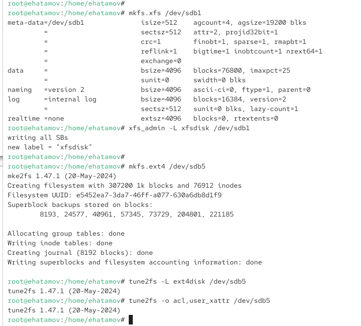

Форматирование XFS

## Форматирование EXT4

- Создана EXT4 на **sdb5**
- Метка: *ext4disk*
- Настроены параметры mount: `acl,user_xattr`

[figure not shown]

Форматирование EXT4

## Ручное монтирование EXT4

- Создана точка `/mnt/tmp`
- Монтирование → проверка → размонтирование

[figure not shown]

Ручное монтирование

## Автомонтирование через /etc/fstab

- Получены UUID через `blkid`
- Добавлена строка для **sdb1 → /mnt/data**
- Проверено через `mount -a`

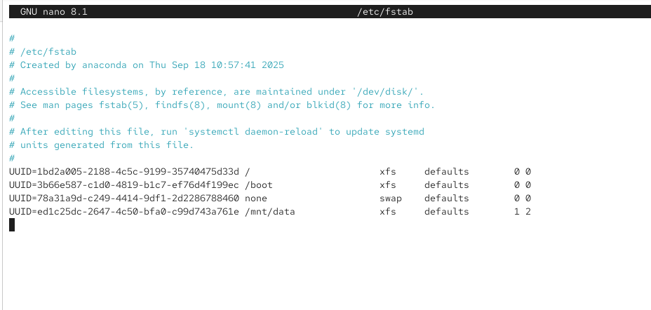

fstab настройка

# Самостоятельная работа

## Создание двух GPT-разделов

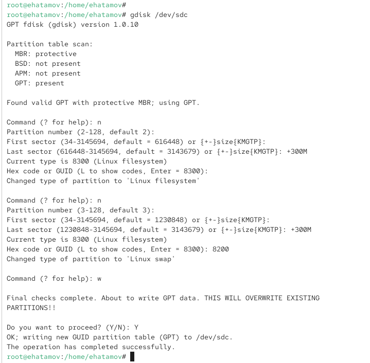

Создание двух разделов

## Форматирование и настройка swap

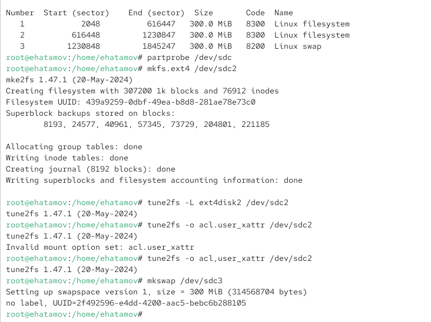

Форматирование и swap

## Автомонтирование новых разделов

- **EXT4 → /mnt/data-ext**
- **swap → автоматическая активация**
- Проверено после перезагрузки

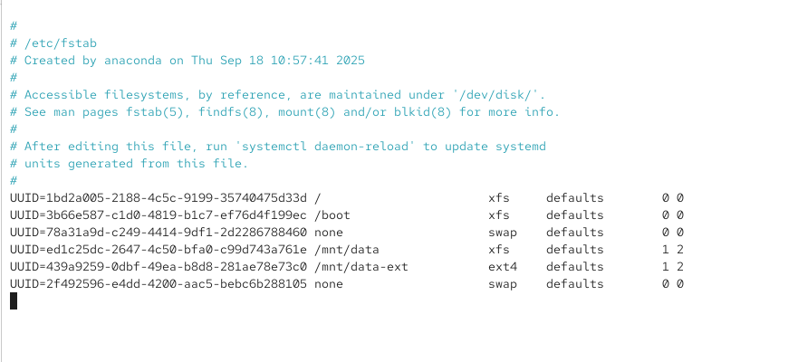

fstab настройка 2

## Проверка монтирования и swap

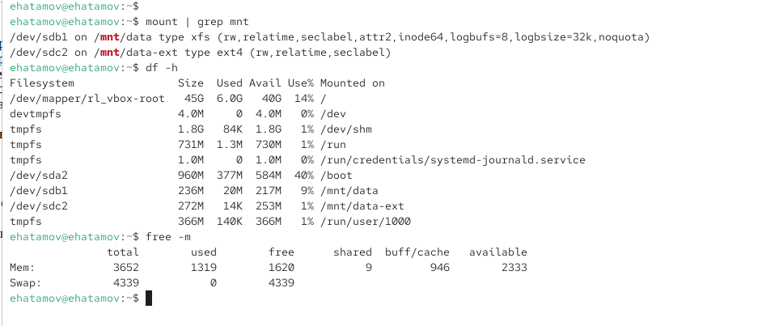

Проверка системы

# Итоги работы

## Вывод

- Изучена разметка дисков в схемах **MBR и GPT**
- Созданы и настроены файловые системы **XFS** и **EXT4**
- Освоено ручное и автоматическое монтирование
- Настроены и активированы разделы подкачки
- Закреплены навыки работы с `/etc/fstab` и UUID